# LinearRegression-Basketball

Sanyamc

Saturday, April 18, 2015

# Moneyball –> Basketball

This is part of recitation for Linear regression where we are going to explore Basketball team’s data sets and apply moneyball techniques there.

Lets load both the available datasets basketball train and basketball test in R

```r
nba_train<-read.csv('E:\\github\\Courses\\Analytics-Edge\\DataSets\\nba_train.csv')
nba_test<-read.csv("E:\\github\\Courses\\Analytics-Edge\\DataSets\\nba_test.csv")

str(nba_test)
```

```
## 'data.frame':    28 obs. of  20 variables:
##  $ SeasonEnd: int  2013 2013 2013 2013 2013 2013 2013 2013 2013 2013 ...
##  $ Team     : Factor w/ 28 levels "Atlanta Hawks",..: 1 2 3 4 5 6 7 8 9 10 ...
##  $ Playoffs : int  1 1 0 1 0 0 1 0 1 1 ...
##  $ W        : int  44 49 21 45 24 41 57 29 47 45 ...
##  $ PTS      : int  8032 7944 7661 7641 7913 8293 8704 7778 8296 8688 ...
##  $ oppPTS   : int  7999 7798 8418 7615 8297 8342 8287 8105 8223 8403 ...
##  $ FG       : int  3084 2942 2823 2926 2993 3182 3339 2979 3130 3124 ...
##  $ FGA      : int  6644 6544 6649 6698 6901 6892 6983 6638 6840 6782 ...
##  $ X2P      : int  2378 2314 2354 2480 2446 2576 2818 2466 2472 2257 ...
##  $ X2PA     : int  4743 4784 5250 5433 5320 5264 5465 5198 5208 4413 ...
##  $ X3P      : int  706 628 469 446 547 606 521 513 658 867 ...
##  $ X3PA     : int  1901 1760 1399 1265 1581 1628 1518 1440 1632 2369 ...
##  $ FT       : int  1158 1432 1546 1343 1380 1323 1505 1307 1378 1573 ...
##  $ FTA      : int  1619 1958 2060 1738 1826 1669 2148 1870 1744 2087 ...
##  $ ORB      : int  758 1047 917 1026 1004 767 1092 991 885 909 ...
##  $ DRB      : int  2593 2460 2389 2514 2359 2670 2601 2463 2801 2652 ...
##  $ AST      : int  2007 1668 1587 1886 1694 1906 2002 1742 1845 1902 ...
##  $ STL      : int  664 599 591 588 647 648 762 574 567 679 ...
##  $ BLK      : int  369 391 479 417 334 454 533 400 346 359 ...
##  $ TOV      : int  1219 1206 1153 1171 1149 1144 1253 1241 1236 1348 ...
```

As we can see there are tons of variables here.

Our goal is to find out how many wins a team needs to win in order to make the playoffs.

```r
table(nba_train$W,nba_train$Playoff)
```

```
##
##       0  1
##   11  2  0
##   12  2  0
##   13  2  0
##   14  2  0
##   15 10  0
##   16  2  0
##   17 11  0
##   18  5  0
##   19 10  0
##   20 10  0
##   21 12  0
##   22 11  0
##   23 11  0
```

[output cut: 46 more lines]

As we can see from the table command, a team that wins about 42 games is gets a playoffs spot. i.e. in the past team that wins 42 games have been to playoffs 29 times and not in playoffs around 8 times.

Just like the runs difference, we are going to use the points difference and see the linear relation between the two.

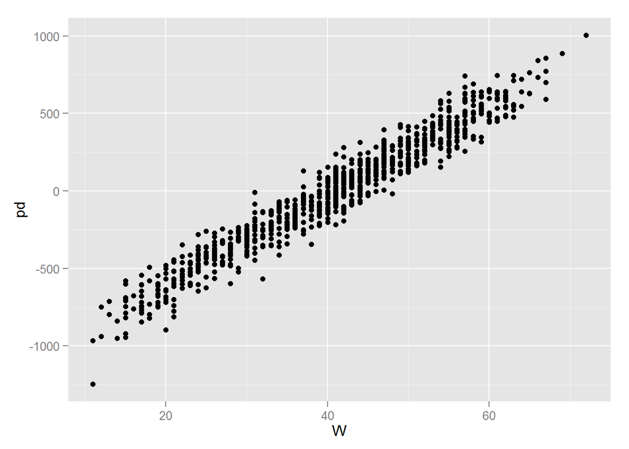

```r
nba_train$pd<-nba_train$PTS-nba_train$oppPTS
library('ggplot2')
ggplot(aes(x=W,y=pd),data=nba_train)+geom_point()
```

Obviously there is a **strong** linear relation between points diff and wins. Lets create a linear model

```r
model1<-lm(W~pd,nba_train)
summary(model1)
```

```
##
## Call:
## lm(formula = W ~ pd, data = nba_train)
##
## Residuals:
##     Min      1Q  Median      3Q     Max
## -9.7393 -2.1018 -0.0672  2.0265 10.6026
##
## Coefficients:
##              Estimate Std. Error t value Pr(>|t|)
## (Intercept) 4.100e+01  1.059e-01   387.0   <2e-16 ***
## pd          3.259e-02  2.793e-04   116.7   <2e-16 ***
## ---
## Signif. codes:  0 '***' 0.001 '**' 0.01 '*' 0.05 '.' 0.1 ' ' 1
##
## Residual standard error: 3.061 on 833 degrees of freedom
## Multiple R-squared:  0.9423, Adjusted R-squared:  0.9423
## F-statistic: 1.361e+04 on 1 and 833 DF,  p-value: < 2.2e-16
```

As we can see that this a good model as R2 is close to 1. Our linear regression eq is W = 41+.03259(pd)

In terms of points difference for a team making playoffs(winning 42 games) team needs to have 1/.0326 pointsdiff which comes out to be around 31.

Now the PD largly depends on PS and PC

```r
model1<-lm(PTS~X2PA+X3PA+FTA+ORB+DRB+AST+STL+BLK+TOV,data=nba_train)
summary(model1)
```

```
##
## Call:
## lm(formula = PTS ~ X2PA + X3PA + FTA + ORB + DRB + AST + STL +
##     BLK + TOV, data = nba_train)
##
## Residuals:
##     Min      1Q  Median      3Q     Max
## -527.40 -119.83    7.83  120.67  564.71
##
## Coefficients:
##               Estimate Std. Error t value Pr(>|t|)
## (Intercept) -2.051e+03  2.035e+02 -10.078   <2e-16 ***
## X2PA         1.043e+00  2.957e-02  35.274   <2e-16 ***
## X3PA         1.259e+00  3.843e-02  32.747   <2e-16 ***
## FTA          1.128e+00  3.373e-02  33.440   <2e-16 ***
## ORB         -9.554e-01  7.792e-02 -12.261   <2e-16 ***
## DRB          3.883e-02  6.157e-02   0.631   0.5285
## AST          8.858e-01  4.396e-02  20.150   <2e-16 ***
## STL         -1.992e-01  9.181e-02  -2.169   0.0303 *
## BLK         -5.576e-02  8.782e-02  -0.635   0.5256
## TOV         -2.475e-02  6.118e-02  -0.405   0.6859
## ---
## Signif. codes:  0 '***' 0.001 '**' 0.01 '*' 0.05 '.' 0.1 ' ' 1
##
## Residual standard error: 185.5 on 825 degrees of freedom
## Multiple R-squared:  0.8992, Adjusted R-squared:  0.8981
## F-statistic: 817.3 on 9 and 825 DF,  p-value: < 2.2e-16
```

Now lets remove the variables which are less sig. From the above table that would be TOV (p very high)

```r
model2<-lm(PTS~X2PA+X3PA+FTA+ORB+DRB+AST+STL+BLK,data=nba_train)
summary(model2)
```

```
##
## Call:
## lm(formula = PTS ~ X2PA + X3PA + FTA + ORB + DRB + AST + STL +
##     BLK, data = nba_train)
##
## Residuals:
##     Min      1Q  Median      3Q     Max
## -526.79 -121.09    6.37  120.74  565.94
##
## Coefficients:
##               Estimate Std. Error t value Pr(>|t|)
## (Intercept) -2.077e+03  1.931e+02 -10.755   <2e-16 ***
## X2PA         1.044e+00  2.951e-02  35.366   <2e-16 ***
## X3PA         1.263e+00  3.703e-02  34.099   <2e-16 ***
## FTA          1.125e+00  3.308e-02  34.023   <2e-16 ***
## ORB         -9.581e-01  7.758e-02 -12.350   <2e-16 ***
## DRB          3.892e-02  6.154e-02   0.632   0.5273
## AST          8.861e-01  4.393e-02  20.173   <2e-16 ***
## STL         -2.068e-01  8.984e-02  -2.301   0.0216 *
## BLK         -5.863e-02  8.749e-02  -0.670   0.5029
## ---
## Signif. codes:  0 '***' 0.001 '**' 0.01 '*' 0.05 '.' 0.1 ' ' 1
##
## Residual standard error: 185.4 on 826 degrees of freedom
## Multiple R-squared:  0.8991, Adjusted R-squared:  0.8982
## F-statistic: 920.4 on 8 and 826 DF,  p-value: < 2.2e-16
```

```r
model3<-lm(PTS~X2PA+X3PA+FTA+ORB+DRB+AST+STL,data=nba_train)
summary(model3)
```

```
##
## Call:
## lm(formula = PTS ~ X2PA + X3PA + FTA + ORB + DRB + AST + STL,
##     data = nba_train)
##
## Residuals:
##     Min      1Q  Median      3Q     Max
## -525.04 -121.76    7.95  118.43  561.78
##
## Coefficients:
##               Estimate Std. Error t value Pr(>|t|)
## (Intercept) -2.076e+03  1.930e+02 -10.756   <2e-16 ***
## X2PA         1.048e+00  2.888e-02  36.272   <2e-16 ***
## X3PA         1.269e+00  3.590e-02  35.339   <2e-16 ***
## FTA          1.125e+00  3.306e-02  34.028   <2e-16 ***
## ORB         -9.681e-01  7.611e-02 -12.720   <2e-16 ***
## DRB          2.415e-02  5.744e-02   0.420   0.6743
## AST          8.847e-01  4.386e-02  20.172   <2e-16 ***
## STL         -2.137e-01  8.921e-02  -2.395   0.0168 *
## ---
## Signif. codes:  0 '***' 0.001 '**' 0.01 '*' 0.05 '.' 0.1 ' ' 1
##
## Residual standard error: 185.4 on 827 degrees of freedom
## Multiple R-squared:  0.8991, Adjusted R-squared:  0.8982
## F-statistic:  1053 on 7 and 827 DF,  p-value: < 2.2e-16
```

Although R^2 remained the same but other measures like Root mean squared error could have increased so check them out before sticking with the new model.

Now using this model3 lets make prediction for 2012-2013 season in the test data set.

```r
outcome<-predict(model3,nba_test)
summary(outcome)
```

```
##    Min. 1st Qu.  Median    Mean 3rd Qu.    Max.
##    7506    7843    8004    8034    8171    8622
```

```r
SSE<-sum((nba_test$PTS-outcome)^2)
SST<-sum((nba_test$PTS-mean(nba_train$PTS))^2)
R2<-1-(SSE/SST)
RMSE<-sqrt(SSE/length(nba_test$PTS))
```